# Bank Marketing - Full Report

Applied Machine Learning and Predictive Modelling 1 - FS26

Hanieh Jebeli, Enerel Khuyag, Aurelio Wyrsch

2026-06-07

# 1. Data Source & Context

*Section lead: Hanieh Jebeli*

The dataset comes from the UCI Machine Learning Repository and contains records of **45,211 phone marketing calls** made by a Portuguese bank between May 2008 and November 2010. Each row represents one call to one client, with 17 features describing the client’s profile, the campaign contact history, and the outcome of previous campaigns.

**Research question:**

> *“Can we predict which bank customers will subscribe to a term deposit before we call them - and what drives their decision?”*

This is a practical business problem: a model that correctly identifies likely subscribers allows a bank to focus its marketing resources on the right people, reducing cost and improving conversion rates.

# 2. Data Loading & Initial Inspection

*Section lead: Hanieh Jebeli*

```r
# File uses semicolons as separator
bank_raw <- read.csv("../data/bank-full.csv", sep = ";")

dim(bank_raw)
head(bank_raw, 5)
str(bank_raw)
```

The raw dataset has **45211 rows** and **17 columns**.

| Variable | Type | Description |
| --- | --- | --- |
| `age` | Continuous | Client age in years |
| `job` | Categorical | Type of job (12 levels) |
| `marital` | Categorical | Marital status (married, single, divorced) |
| `education` | Categorical | Education level (primary, secondary, tertiary, unknown) |
| `default` | Binary | Has credit in default? (yes/no) |
| `balance` | Continuous | Average yearly balance in euros |
| `housing` | Binary | Has housing loan? (yes/no) |
| `loan` | Binary | Has personal loan? (yes/no) |
| `contact` | Categorical | Contact type (cellular, telephone, unknown) |
| `day` | Continuous | Last contact day of month |
| `month` | Categorical | Last contact month (jan-dec) |
| `duration` | Continuous | Last call duration in seconds |
| `campaign` | Count | Number of contacts during this campaign |
| `pdays` | Continuous | Days since last contact (-1 = never contacted before) |
| `previous` | Count | Number of contacts before this campaign |
| `poutcome` | Categorical | Outcome of previous campaign (success, failure, other, unknown) |
| `y` | Binary | **Target** - subscribed? (yes/no) |

# 3. Data Cleaning

*Section lead: Hanieh Jebeli*

## 3.1 Recode and engineer variables

All character variables are converted to R factors with meaningful labels. Age is kept as-is (already in years). We derive two new variables: `log_balance` for the Linear Model (balance is an amount variable requiring log-transformation) and `pdays_clean` which recodes -1 as NA for clarity.

```r
bank <- bank_raw %>%
  mutate(
    # Target: yes/no -> factor
    subscribed = factor(y, levels = c("no", "yes"),
                        labels = c("No", "Yes")),

    # Job: 12 levels - satisfies course 3+ categorical requirement
    job = factor(job),

    # Marital: 3 levels
    marital = factor(marital,
                     levels = c("single", "married", "divorced")),

    # Education: 4 ordered levels
    education = factor(education,
                       levels = c("unknown", "primary", "secondary", "tertiary"),
                       ordered = TRUE),

    # Binary variables as proper factors
    default = factor(default, levels = c("no", "yes")),
    housing = factor(housing, levels = c("no", "yes")),
    loan    = factor(loan,    levels = c("no", "yes")),

    # Contact type
    contact = factor(contact),

    # Month as ordered factor
    month = factor(month,
                   levels = c("jan","feb","mar","apr","may","jun",
                              "jul","aug","sep","oct","nov","dec"),
                   ordered = TRUE),

    # Previous campaign outcome
    poutcome = factor(poutcome,
                      levels = c("unknown","other","failure","success")),

    # pdays: -1 means never contacted - recode to NA for clarity
    pdays_clean = ifelse(pdays == -1, NA, pdays),

    # Flag: was client contacted before this campaign?
    prev_contacted = factor(ifelse(previous == 0, "No", "Yes")),

    # log balance - balance is an amount variable, needs log transform for LM
    # some balances are negative (overdraft) - shift first
    balance_shifted = balance - min(balance) + 1,
    log_balance     = log(balance_shifted)
  ) %>%
  select(-y)   # drop original target - we use 'subscribed' instead

glimpse(bank)
```

## 3.2 Missing values

```r
colSums(is.na(bank))
```

No missing values in the original columns. The `pdays_clean` column has NAs by design - these represent clients who were never contacted before this campaign (coded as -1 in the raw data). This is expected and handled correctly.

## 3.3 Check for outliers

We remove two types of impossible values: calls with `campaign > 30` (data entry errors) and calls with `duration = 0` (calls that never took place).

```r
# Campaign: number of contacts - check for unreasonable values
cat("campaign range:", range(bank$campaign), "\n")
cat("campaign > 30: ", sum(bank$campaign > 30), "rows\n")

# Duration: call length in seconds
cat("duration range:", range(bank$duration), "\n")
cat("duration = 0:  ", sum(bank$duration == 0), "rows\n")

# Balance: can be negative (overdraft) - that is valid
cat("balance range:", range(bank$balance), "\n")
```

```r
cat("Rows before cleaning:", nrow(bank), "\n")
```

```
## Rows before cleaning: 45211
```

```r
bank_clean <- bank %>%
  filter(
    campaign <= 30,    # more than 30 calls to one client is a data error
    duration > 0       # duration = 0 means call never happened - remove
  )

cat("Rows after cleaning: ", nrow(bank_clean), "\n")
```

```
## Rows after cleaning:  45149
```

```r
cat("Rows removed:        ", nrow(bank) - nrow(bank_clean), "\n")
```

```
## Rows removed:         62
```

3.4 Dataset summary

```r
summary(bank_clean %>%
          select(age, balance, duration, campaign, previous))
```

```r
bank_clean %>%
  count(subscribed) %>%
  mutate(pct = paste0(round(100 * n / sum(n), 1), "%")) %>%
  kable(caption = "Target variable distribution")
```

Target variable distribution

| subscribed | n | pct |
| --- | --- | --- |
| No | 39861 | 88.3% |
| Yes | 5288 | 11.7% |

The classes are **imbalanced** - around 88% did not subscribe and 12% did. This is realistic for marketing data and will need to be considered when evaluating model performance (accuracy alone is not enough - we will use AUC).

# 4. Exploratory Data Analysis

*Section lead: Hanieh Jebeli*

## 4.1 Subscription rate by job type

We compute the subscription rate per job category and rank them. This reveals which client segments are most receptive to the product.

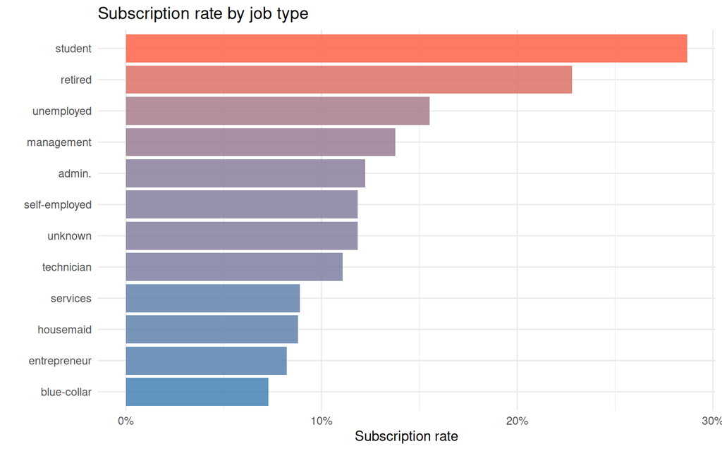

```r
bank_clean %>%
  group_by(job) %>%
  summarise(rate = mean(subscribed == "Yes")) %>%
  arrange(desc(rate)) %>%
  ggplot(aes(x = reorder(job, rate), y = rate, fill = rate)) +
  geom_col(alpha = 0.85) +
  scale_fill_gradient(low = "steelblue", high = "tomato") +
  scale_y_continuous(labels = percent) +
  coord_flip() +
  labs(title = "Subscription rate by job type",
       x = "", y = "Subscription rate") +
  theme_minimal() +
  theme(legend.position = "none")
```

## 4.2 Age and balance distribution by outcome

Boxplots compare the distribution of age and account balance between subscribers and non-subscribers.

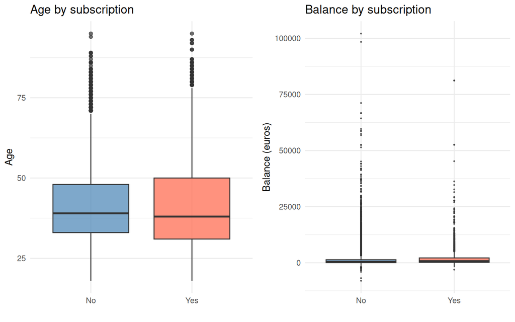

```r
p1 <- ggplot(bank_clean, aes(x = subscribed, y = age, fill = subscribed)) +
  geom_boxplot(alpha = 0.7) +
  scale_fill_manual(values = c("steelblue", "tomato")) +
  labs(title = "Age by subscription", x = "", y = "Age") +
  theme_minimal() + theme(legend.position = "none")

p2 <- ggplot(bank_clean, aes(x = subscribed, y = balance, fill = subscribed)) +
  geom_boxplot(alpha = 0.7, outlier.size = 0.3) +
  scale_fill_manual(values = c("steelblue", "tomato")) +
  labs(title = "Balance by subscription", x = "", y = "Balance (euros)") +
  theme_minimal() + theme(legend.position = "none")

grid.arrange(p1, p2, ncol = 2)
```

## 4.3 Call duration - strongest single predictor

We plot the distribution of call duration in minutes, split by subscription outcome.

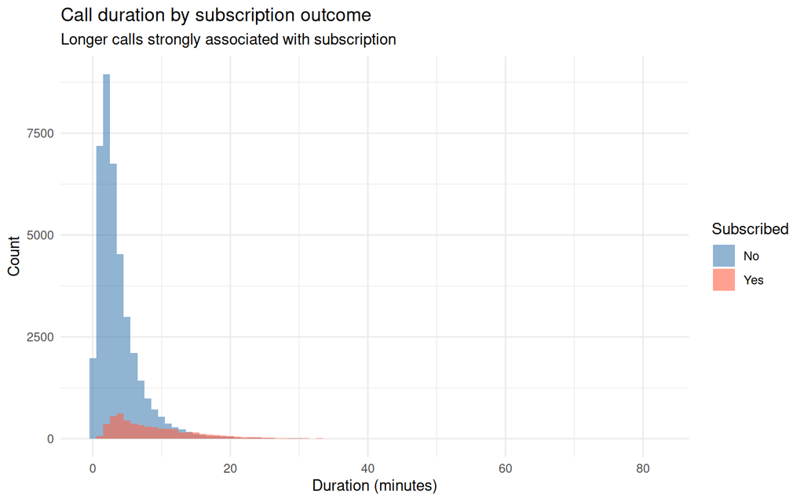

```r
ggplot(bank_clean, aes(x = duration / 60, fill = subscribed)) +
  geom_histogram(binwidth = 1, position = "identity", alpha = 0.6) +
  scale_fill_manual(values = c("steelblue", "tomato")) +
  labs(title = "Call duration by subscription outcome",
       subtitle = "Longer calls strongly associated with subscription",
       x = "Duration (minutes)", y = "Count", fill = "Subscribed") +
  theme_minimal()
```

Call duration is the single strongest predictor in the dataset. Customers who subscribed had much longer calls on average. Note: this variable cannot be used for prediction in a real deployment (we don’t know duration before calling) - but it is valid for a retrospective analysis.

## 4.4 Campaign contacts - count variable

We show how subscription rate changes with the number of times a client was contacted during the campaign.

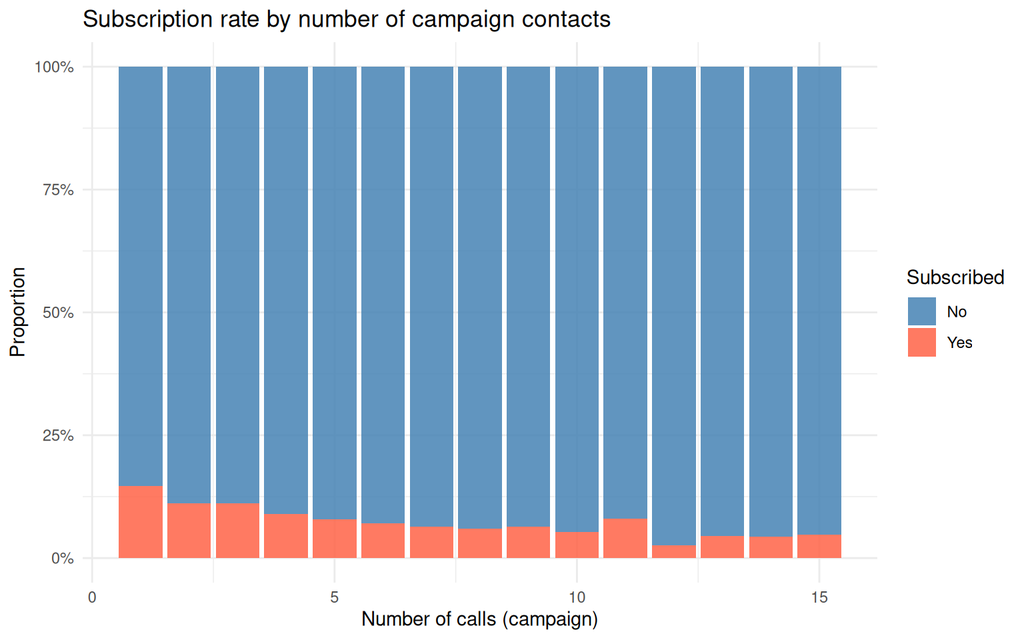

```r
bank_clean %>%
  filter(campaign <= 15) %>%
  ggplot(aes(x = campaign, fill = subscribed)) +
  geom_bar(position = "fill", alpha = 0.85) +
  scale_fill_manual(values = c("steelblue", "tomato")) +
  scale_y_continuous(labels = percent) +
  labs(title = "Subscription rate by number of campaign contacts",
       x = "Number of calls (campaign)", y = "Proportion",
       fill = "Subscribed") +
  theme_minimal()
```

Subscription rate drops sharply after 2-3 contacts. Clients contacted many times are much less likely to subscribe - diminishing returns are clearly visible.

## 4.5 Smoother: age vs call duration

A LOESS smoother shows the non-linear relationship between client age and call duration among subscribers.

[figure not shown]

```r
ggplot(bank_clean, aes(x = age, y = duration / 60, color = subscribed)) +
  geom_smooth(method = "loess", se = TRUE) +
  scale_color_manual(values = c("steelblue", "tomato")) +
  labs(title = "Call duration vs age (LOESS smoother)",
       x = "Age (years)", y = "Duration (minutes)", color = "Subscribed") +
  theme_minimal()
```

## 4.6 Correlation matrix

We compute Pearson correlations among the continuous and count variables to check for multicollinearity.

```r
bank_clean %>%
  select(age, balance, duration, campaign, previous, day) %>%
  cor(use = "complete.obs") %>%
  round(2) %>%
  kable(caption = "Pearson correlations - continuous and count variables")
```

Pearson correlations - continuous and count variables

|  | age | balance | duration | campaign | previous | day |
| --- | --- | --- | --- | --- | --- | --- |
| age | 1.00 | 0.10 | 0.00 | 0.01 | 0.00 | -0.01 |
| balance | 0.10 | 1.00 | 0.02 | -0.02 | 0.02 | 0.00 |
| duration | 0.00 | 0.02 | 1.00 | -0.08 | 0.00 | -0.03 |
| campaign | 0.01 | -0.02 | -0.08 | 1.00 | -0.03 | 0.16 |
| previous | 0.00 | 0.02 | 0.00 | -0.03 | 1.00 | -0.05 |
| day | -0.01 | 0.00 | -0.03 | 0.16 | -0.05 | 1.00 |

Most variables show weak mutual correlations, which is good - it means multicollinearity is not a major concern for the models.

# 5. Feature Engineering

*Section lead: Hanieh Jebeli*

We create four derived variables used across all models: a binary numeric target for aggregation, age groups for the Poisson model, duration in minutes for readability, and education as a numeric scale for the Linear Model.

```r
bank_model <- bank_clean %>%
  mutate(
    # Numeric target for aggregation (Poisson)
    subscribed_num = as.integer(subscribed == "Yes"),

    # Age groups for Poisson aggregation
    age_group = cut(age,
                    breaks = c(0, 30, 40, 50, 60, 100),
                    labels = c("<30", "30-40", "40-50", "50-60", "60+"),
                    right  = FALSE),

    # Duration in minutes - more interpretable
    duration_min = duration / 60,

    # Education as numeric for LM
    education_num = as.integer(education)
  )

glimpse(bank_model %>% select(subscribed_num, age_group, duration_min, education_num))
```

# 6. Linear Model - Predicting log(balance)

*Section lead: Hanieh Jebeli*

We use a Linear Model to understand which client characteristics predict their account balance. Balance is a continuous **amount variable** - after shifting to make all values positive, we log-transform it as required for this type of response.

**Model:** lm(log_balance ~ age + job + education_num + housing + loan + marital + default)

## 6.1 Fit

We fit the linear model using all selected demographic and financial predictors. The model is fitted on `bank_model` which contains the log-transformed balance and the numeric education scale created in the feature engineering step.

```r
lm_fit <- lm(
  log_balance ~ age + job + education_num + housing + loan + marital + default,
  data = bank_model
)
```

## 6.2 Coefficient interpretation

The table below shows the estimated coefficients, their confidence intervals, and the percentage change in balance associated with each predictor.

```r
broom::tidy(lm_fit, conf.int = TRUE) %>%
  filter(term != "(Intercept)") %>%
  mutate(
    pct_change = round((exp(estimate) - 1) * 100, 2),
    across(where(is.numeric), ~round(., 4))
  ) %>%
  kable(caption = "LM coefficients - effect on log(balance)")
```

LM coefficients - effect on log(balance)

| term | estimate | std.error | statistic | p.value | conf.low | conf.high | pct_change |
| --- | --- | --- | --- | --- | --- | --- | --- |
| age | 0.0024 | 0.0001 | 20.2402 | 0.0000 | 0.0022 | 0.0026 | 0.24 |
| jobblue-collar | 0.0003 | 0.0037 | 0.0877 | 0.9301 | -0.0069 | 0.0075 | 0.03 |
| jobentrepreneur | 0.0179 | 0.0062 | 2.8963 | 0.0038 | 0.0058 | 0.0299 | 1.80 |
| jobhousemaid | 0.0026 | 0.0067 | 0.3893 | 0.6971 | -0.0105 | 0.0157 | 0.26 |
| jobmanagement | 0.0325 | 0.0038 | 8.5580 | 0.0000 | 0.0251 | 0.0400 | 3.30 |
| jobretired | 0.0110 | 0.0058 | 1.8996 | 0.0575 | -0.0003 | 0.0224 | 1.11 |
| jobself-employed | 0.0268 | 0.0060 | 4.4422 | 0.0000 | 0.0150 | 0.0386 | 2.72 |
| jobservices | -0.0065 | 0.0043 | -1.4859 | 0.1373 | -0.0150 | 0.0021 | -0.64 |
| jobstudent | 0.0354 | 0.0076 | 4.6316 | 0.0000 | 0.0204 | 0.0504 | 3.60 |
| jobtechnician | 0.0064 | 0.0038 | 1.6923 | 0.0906 | -0.0010 | 0.0138 | 0.64 |
| jobunemployed | 0.0214 | 0.0065 | 3.3062 | 0.0009 | 0.0087 | 0.0341 | 2.16 |
| jobunknown | 0.0277 | 0.0128 | 2.1711 | 0.0299 | 0.0027 | 0.0527 | 2.81 |
| education_num | 0.0115 | 0.0015 | 7.4953 | 0.0000 | 0.0085 | 0.0146 | 1.16 |
| housingyes | -0.0160 | 0.0021 | -7.6751 | 0.0000 | -0.0200 | -0.0119 | -1.58 |
| loanyes | -0.0529 | 0.0027 | -19.6189 | 0.0000 | -0.0582 | -0.0476 | -5.16 |
| maritalmarried | -0.0055 | 0.0025 | -2.1854 | 0.0289 | -0.0104 | -0.0006 | -0.55 |
| maritaldivorced | -0.0339 | 0.0037 | -9.2238 | 0.0000 | -0.0411 | -0.0267 | -3.33 |
| defaultyes | -0.1482 | 0.0074 | -20.0474 | 0.0000 | -0.1626 | -0.1337 | -13.77 |

## 6.3 Diagnostics

We check the four standard linear model diagnostic plots: residuals vs fitted values (checking linearity), Q-Q plot (checking normality of residuals), scale-location (checking homoscedasticity), and residuals vs leverage (checking for influential observations).

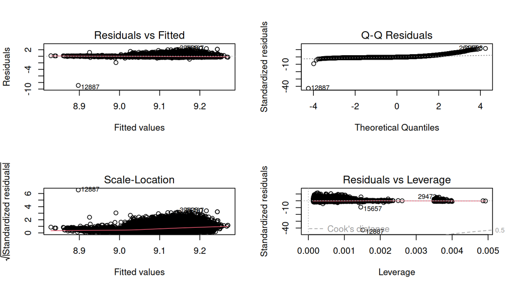

```r
par(mfrow = c(2, 2))
plot(lm_fit)
```

```r
par(mfrow = c(1, 1))
```

## 6.4 Performance

We report R² and RMSE on the log scale. R² measures the proportion of variance in log(balance) explained by the predictors, while RMSE gives the average prediction error in log units.

```r
cat(
  "R-squared:        ", round(summary(lm_fit)$r.squared, 4), "\n",
  "RMSE (log scale): ", round(sqrt(mean(lm_fit$residuals^2)), 4), "\n"
)
```

```
## R-squared:         0.0451
##  RMSE (log scale):  0.208
```

# 7. Poisson GLM - Predicting subscription counts per group

*Section lead: Hanieh Jebeli*

The Poisson GLM models **count data** - non-negative integers. We aggregate the data by age group, education, and housing status, and model the **number of clients who subscribed** in each group. The offset log(n) adjusts for group size so we model the **rate** not the raw count.

## 7.1 Aggregate data

We group the data by age group, education level, and housing loan status, then count how many clients subscribed in each cell. Groups with fewer than 10 observations are removed to avoid unstable rate estimates in small cells.

```r
bank_agg <- bank_model %>%
  group_by(age_group, education, housing) %>%
  summarise(
    n                = n(),
    subscribed_count = sum(subscribed_num),
    .groups          = "drop"
  ) %>%
  filter(n >= 10)
```

## 7.2 Fit

We fit the Poisson GLM with a log link. The `offset(log(n))` term ensures that we model the subscription rate per client rather than the raw count without it.

```r
poisson_fit <- glm(
  subscribed_count ~ age_group + education + housing + offset(log(n)),
  data   = bank_agg,
  family = poisson(link = "log")
)
```

## 7.3 Rate ratios

```r
broom::tidy(poisson_fit, conf.int = TRUE) %>%
  filter(term != "(Intercept)") %>%
  mutate(
    rate_ratio = round(exp(estimate), 3),
    rr_lower   = round(exp(conf.low), 3),
    rr_upper   = round(exp(conf.high), 3),
    p.value    = round(p.value, 4)
  ) %>%
  select(term, rate_ratio, rr_lower, rr_upper, p.value) %>%
  kable(caption = "Poisson GLM - Rate Ratios (exp of coefficients)")
```

Poisson GLM - Rate Ratios (exp of coefficients)

| term | rate_ratio | rr_lower | rr_upper | p.value |
| --- | --- | --- | --- | --- |
| age_group30-40 | 0.610 | 0.564 | 0.660 | 0e+00 |
| age_group40-50 | 0.538 | 0.492 | 0.587 | 0e+00 |
| age_group50-60 | 0.506 | 0.460 | 0.557 | 0e+00 |
| age_group60+ | 1.596 | 1.435 | 1.775 | 0e+00 |
| education.L | 1.202 | 1.098 | 1.319 | 1e-04 |
| education.Q | 1.372 | 1.266 | 1.485 | 0e+00 |
| education.C | 0.877 | 0.819 | 0.938 | 1e-04 |
| housingyes | 0.512 | 0.483 | 0.542 | 0e+00 |

**Key interpretations:**

- **Age group:** Younger clients under 30 and older clients above 60 show higher subscription rates than middle-aged groups. The rate ratio tells us exactly how much more likely each group is to subscribe relative to the reference category.
- **Education (tertiary):** Tertiary-educated clients subscribe at a higher rate than those with primary education, reflecting greater financial product awareness and disposable income.
- **Housing loan (yes):** Clients with a housing loan are less likely to subscribe, as an existing financial commitment reduces appetite for new products.

## 7.4 Visualise predicted rates

We plot the model’s predicted subscription rates across age groups, split by education level and faceted by housing loan status. This gives an intuitive picture of how the three predictors interact.

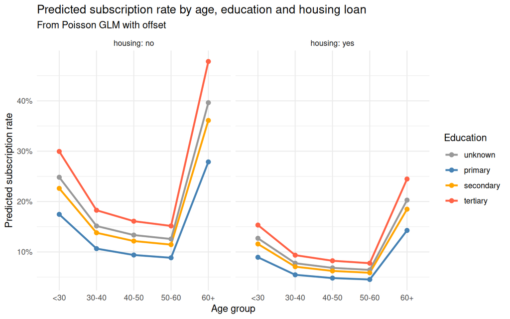

```r
bank_agg$predicted_rate <- predict(poisson_fit, type = "response") / bank_agg$n

ggplot(bank_agg,
       aes(x = age_group, y = predicted_rate,
           color = education, group = education)) +
  geom_line(linewidth = 1) +
  geom_point(size = 2) +
  facet_wrap(~housing, labeller = label_both) +
  scale_color_manual(values = c("grey60", "steelblue", "orange", "tomato")) +
  scale_y_continuous(labels = percent) +
  labs(title = "Predicted subscription rate by age, education and housing loan",
       subtitle = "From Poisson GLM with offset",
       x = "Age group", y = "Predicted subscription rate",
       color = "Education") +
  theme_minimal()
```

## 7.5 Model fit

The McFadden pseudo-R² and deviance reduction confirm how well the model improves over a null model that predicts the same rate for every group.

```r
cat(
  "Null deviance:     ", round(poisson_fit$null.deviance, 1), "on", poisson_fit$df.null, "df\n",
  "Residual deviance: ", round(poisson_fit$deviance, 1), "on", poisson_fit$df.residual, "df\n",
  "AIC:               ", round(AIC(poisson_fit), 1), "\n",
  "McFadden pseudo-R2:", round(1 - poisson_fit$deviance / poisson_fit$null.deviance, 3), "\n"
)
```

```
## Null deviance:      1622.3 on 39 df
##  Residual deviance:  105.9 on 31 df
##  AIC:                367.5
##  McFadden pseudo-R2: 0.935
```

# 8. Summary

The **Poisson GLM** revealed a U-shaped age effect: clients under 30 and above 60 subscribe at the highest rates. Education amplifies this effect — tertiary-educated clients across all age groups subscribe more. Housing loans consistently reduce subscription rates, suggesting that existing financial commitments are a key barrier.

Together, these two models suggest that the bank should prioritise young and older clients with higher education and no housing loan — and be cautious about over-contacting middle-aged clients who are the least responsive segment.

# 9. Binomial GLM - Predicting subscription

*Section lead: Enerel Khuyag*

Since the response variable **subscribed** is binary (Yes/No), a **Binomial GLM with a logit link** is the natural modelling choice. Unlike a plain linear model, it constrains predicted values to the (0, 1) probability range and models the **log-odds** of subscription as a linear combination of predictors. This makes the coefficients directly interpretable as odds ratios after exponentiation.

## 9.1 Train/Test Split

To evaluate the model on unseen data we use the same 80/20 stratified split strategy as Aurelio’s section, ensuring comparable performance metrics across all models.

```r
set.seed(123)
indices <- createDataPartition(bank_clean$subscribed, p = 0.80, list = FALSE)

bank_train <- bank_clean %>% slice(indices)
bank_test  <- bank_clean %>% slice(-indices)

bank_test_truth     <- bank_test$subscribed
bank_test_truth_bin <- bank_test$subscribed_bin

cat("Training rows:", nrow(bank_train), "\n")
```

```
## Training rows: 36120
```

```r
cat("Test rows:    ", nrow(bank_test),  "\n")
```

```
## Test rows:     9029
```

```r
cat("Subscription rate (train):", round(mean(bank_train$subscribed == "Yes"), 3), "\n")
```

```
## Subscription rate (train): 0.117
```

```r
cat("Subscription rate (test): ", round(mean(bank_test$subscribed  == "Yes"), 3), "\n")
```

```
## Subscription rate (test):  0.117
```

## 9.2 Model Fitting

```r
glm_fit <- glm(
  subscribed_bin ~ age + job + marital + education +
                   default + balance + housing + loan +
                   contact + month + campaign +
                   previous + poutcome,
  data   = bank_train,
  family = binomial(link = "logit")
)

saveRDS(glm_fit, "../models/binomial_fit.rds")

summary(glm_fit)
```

```
##
## Call:
## glm(formula = subscribed_bin ~ age + job + marital + education +
##     default + balance + housing + loan + contact + month + campaign +
##     previous + poutcome, family = binomial(link = "logit"), data = bank_train)
##
## Coefficients:
##                    Estimate Std. Error z value Pr(>|z|)
## (Intercept)      -9.521e-01  1.062e-01  -8.963  < 2e-16 ***
## age               1.096e-04  2.190e-03   0.050 0.960067
## jobblue-collar   -9.811e-02  7.207e-02  -1.361 0.173449
## jobentrepreneur  -1.482e-01  1.225e-01  -1.210 0.226274
## jobhousemaid     -3.052e-01  1.340e-01  -2.277 0.022787 *
## jobmanagement    -6.654e-02  7.311e-02  -0.910 0.362762
## jobretired        4.327e-01  9.596e-02   4.509 6.50e-06 ***
## jobself-employed -1.107e-01  1.112e-01  -0.996 0.319381
## jobservices      -1.115e-01  8.364e-02  -1.333 0.182413
## jobstudent        3.809e-01  1.102e-01   3.455 0.000550 ***
## jobtechnician    -9.765e-02  6.935e-02  -1.408 0.159122
## jobunemployed     1.190e-01  1.089e-01   1.092 0.274765
## jobunknown       -1.441e-01  2.276e-01  -0.633 0.526765
## maritalmarried   -2.745e-01  4.574e-02  -6.002 1.95e-09 ***
## maritaldivorced  -8.103e-02  6.594e-02  -1.229 0.219115
## education.L       8.136e-02  6.584e-02   1.236 0.216543
## education.Q       1.934e-01  5.814e-02   3.327 0.000877 ***
## education.C      -5.593e-02  4.628e-02  -1.208 0.226911
## defaultyes       -1.191e-01  1.675e-01  -0.711 0.477195
## balance           2.002e-05  4.942e-06   4.051 5.11e-05 ***
## housingyes       -5.132e-01  4.283e-02 -11.982  < 2e-16 ***
## loanyes          -3.949e-01  5.957e-02  -6.629 3.38e-11 ***
## contacttelephone -2.188e-01  7.228e-02  -3.028 0.002466 **
## contactunknown   -1.323e+00  7.042e-02 -18.786  < 2e-16 ***
## month.L           5.143e-01  1.096e-01   4.691 2.72e-06 ***
## month.Q          -1.117e-01  1.097e-01  -1.018 0.308880
## month.C           8.815e-01  1.109e-01   7.950 1.86e-15 ***
## month^4          -8.615e-01  1.001e-01  -8.609  < 2e-16 ***
## month^5           5.928e-01  8.142e-02   7.281 3.31e-13 ***
## month^6           1.099e+00  7.707e-02  14.255  < 2e-16 ***
## month^7           5.141e-01  7.950e-02   6.466 1.00e-10 ***
## month^8           1.146e+00  8.203e-02  13.967  < 2e-16 ***
## month^9          -6.929e-01  8.279e-02  -8.370  < 2e-16 ***
## month^10         -3.697e-01  6.551e-02  -5.643 1.67e-08 ***
## month^11          1.867e-01  5.693e-02   3.280 0.001037 **
## campaign         -8.518e-02  9.567e-03  -8.904  < 2e-16 ***
## previous          9.780e-03  6.299e-03   1.553 0.120507
## poutcomeother     1.672e-01  8.384e-02   1.995 0.046093 *
## poutcomefailure  -8.863e-02  6.050e-02  -1.465 0.142898
## poutcomesuccess   2.090e+00  7.028e-02  29.745  < 2e-16 ***
## ---
## Signif. codes:  0 '***' 0.001 '**' 0.01 '*' 0.05 '.' 0.1 ' ' 1
##
## (Dispersion parameter for binomial family taken to be 1)
##
##     Null deviance: 26092  on 36119  degrees of freedom
## Residual deviance: 21792  on 36080  degrees of freedom
## AIC: 21872
##
## Number of Fisher Scoring iterations: 6
```

## 9.3 Coefficient Interpretation

```r
tidy(glm_fit, exponentiate = TRUE, conf.int = TRUE) %>%
  filter(term != "(Intercept)", p.value < 0.05) %>%
  mutate(across(where(is.numeric), ~round(., 3))) %>%
  arrange(desc(estimate)) %>%
  kable(caption = "Significant odds ratios (p < 0.05) — Binomial GLM")
```

Significant odds ratios (p < 0.05) — Binomial GLM

| term | estimate | std.error | statistic | p.value | conf.low | conf.high |
| --- | --- | --- | --- | --- | --- | --- |
| poutcomesuccess | 8.088 | 0.070 | 29.745 | 0.000 | 7.047 | 9.284 |
| month^8 | 3.145 | 0.082 | 13.967 | 0.000 | 2.677 | 3.693 |
| month^6 | 3.000 | 0.077 | 14.255 | 0.000 | 2.579 | 3.489 |
| month.C | 2.414 | 0.111 | 7.950 | 0.000 | 1.943 | 3.001 |
| month^5 | 1.809 | 0.081 | 7.281 | 0.000 | 1.542 | 2.122 |
| month.L | 1.672 | 0.110 | 4.691 | 0.000 | 1.349 | 2.073 |
| month^7 | 1.672 | 0.079 | 6.466 | 0.000 | 1.431 | 1.954 |
| jobretired | 1.541 | 0.096 | 4.509 | 0.000 | 1.277 | 1.860 |
| jobstudent | 1.464 | 0.110 | 3.455 | 0.001 | 1.178 | 1.815 |
| education.Q | 1.213 | 0.058 | 3.327 | 0.001 | 1.082 | 1.359 |
| month^11 | 1.205 | 0.057 | 3.280 | 0.001 | 1.078 | 1.348 |
| poutcomeother | 1.182 | 0.084 | 1.995 | 0.046 | 1.001 | 1.390 |
| balance | 1.000 | 0.000 | 4.051 | 0.000 | 1.000 | 1.000 |
| campaign | 0.918 | 0.010 | -8.904 | 0.000 | 0.901 | 0.935 |
| contacttelephone | 0.803 | 0.072 | -3.028 | 0.002 | 0.696 | 0.924 |
| maritalmarried | 0.760 | 0.046 | -6.002 | 0.000 | 0.695 | 0.831 |
| jobhousemaid | 0.737 | 0.134 | -2.277 | 0.023 | 0.564 | 0.954 |
| month^10 | 0.691 | 0.066 | -5.643 | 0.000 | 0.608 | 0.786 |
| loanyes | 0.674 | 0.060 | -6.629 | 0.000 | 0.599 | 0.756 |
| housingyes | 0.599 | 0.043 | -11.982 | 0.000 | 0.550 | 0.651 |
| month^9 | 0.500 | 0.083 | -8.370 | 0.000 | 0.425 | 0.588 |
| month^4 | 0.423 | 0.100 | -8.609 | 0.000 | 0.347 | 0.514 |
| contactunknown | 0.266 | 0.070 | -18.786 | 0.000 | 0.232 | 0.306 |

**Key interpretations:**

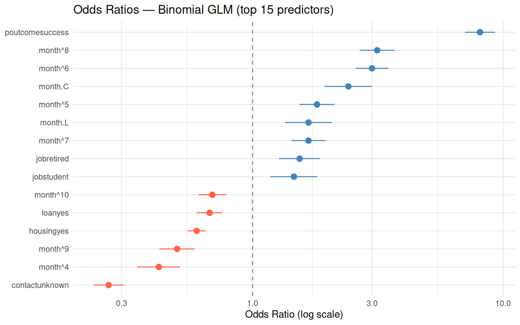

Top 15 predictors by odds ratio (log scale)

```r
tidy(glm_fit, exponentiate = TRUE, conf.int = TRUE) %>%
  filter(term != "(Intercept)") %>%
  slice_max(abs(log(estimate)), n = 15) %>%
  ggplot(aes(x = reorder(term, estimate), y = estimate,
             ymin = conf.low, ymax = conf.high, colour = estimate > 1)) +
  geom_pointrange() +
  geom_hline(yintercept = 1, linetype = "dashed", colour = "grey50") +
  coord_flip() +
  scale_y_log10() +
  scale_colour_manual(values = c("tomato", "steelblue"), guide = "none") +
  labs(title = "Odds Ratios — Binomial GLM (top 15 predictors)",
       x = NULL, y = "Odds Ratio (log scale)") +
  theme_minimal()
```

## 9.4 Model Evaluation

```r
pred_prob_glm  <- as.vector(predict(glm_fit, newdata = bank_test, type = "response"))
pred_class_glm <- factor(if_else(pred_prob_glm > 0.5, "Yes", "No"),
                         levels = c("No", "Yes"))

cm_glm  <- confusionMatrix(pred_class_glm, bank_test_truth, positive = "Yes")
roc_glm <- roc(bank_test_truth_bin, pred_prob_glm)
auc_glm <- as.numeric(auc(roc_glm))

data.frame(
  Metric = c("Accuracy", "Sensitivity", "Specificity", "Balanced Accuracy", "AUC"),
  Value  = round(c(
    cm_glm$overall["Accuracy"],
    cm_glm$byClass["Sensitivity"],
    cm_glm$byClass["Specificity"],
    cm_glm$byClass["Balanced Accuracy"],
    auc_glm
  ), 3)
) %>% kable(caption = "Binomial GLM — Performance Metrics", row.names = FALSE)
```

Binomial GLM — Performance Metrics

| Metric | Value |
| --- | --- |
| Accuracy | 0.895 |
| Sensitivity | 0.174 |
| Specificity | 0.991 |
| Balanced Accuracy | 0.582 |
| AUC | 0.775 |

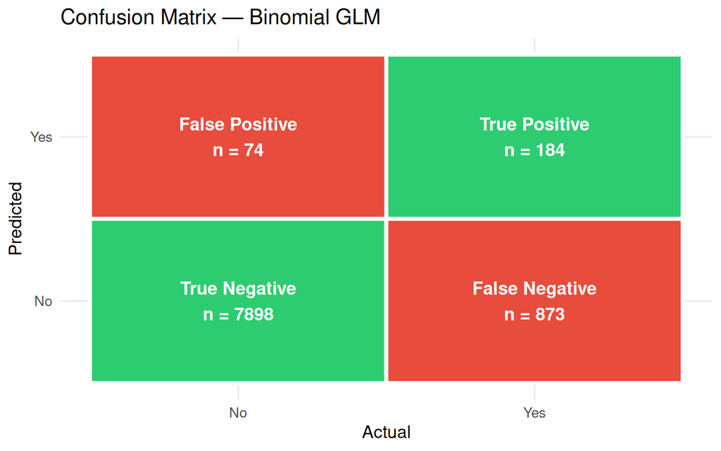

Confusion matrix — Binomial GLM

```r
as.data.frame(cm_glm$table) %>%
  mutate(label = case_when(
    Prediction == "No"  & Reference == "No"  ~ "True Negative",
    Prediction == "Yes" & Reference == "Yes" ~ "True Positive",
    Prediction == "Yes" & Reference == "No"  ~ "False Positive",
    Prediction == "No"  & Reference == "Yes" ~ "False Negative"
  )) %>%
  ggplot(aes(x = Reference, y = Prediction, fill = label)) +
  geom_tile(colour = "white", linewidth = 1.5) +
  geom_text(aes(label = paste0(label, "\nn = ", Freq)),
            size = 5, fontface = "bold", colour = "white") +
  scale_fill_manual(values = c(
    "True Positive"  = "#2ecc71", "True Negative"  = "#2ecc71",
    "False Positive" = "#e74c3c", "False Negative" = "#e74c3c"
  )) +
  labs(title = "Confusion Matrix — Binomial GLM", x = "Actual", y = "Predicted") +
  theme_minimal(base_size = 14) +
  theme(legend.position = "none")
```

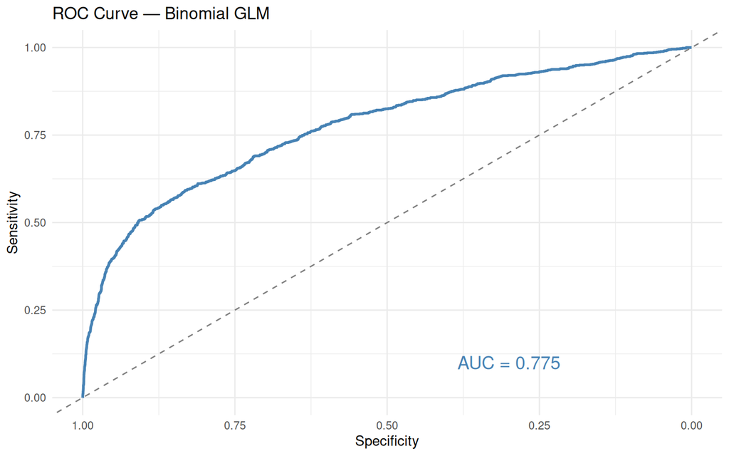

ROC curve — Binomial GLM

```r
ggroc(roc_glm, colour = "steelblue", size = 1) +
  geom_abline(slope = 1, intercept = 1, linetype = "dashed", colour = "grey50") +
  annotate("text", x = 0.3, y = 0.1,
           label = paste0("AUC = ", round(auc_glm, 3)),
           colour = "steelblue", size = 5) +
  labs(title = "ROC Curve — Binomial GLM", x = "Specificity", y = "Sensitivity") +
  theme_minimal()
```

## 9.5 Discussion

The Binomial GLM provides a strong, interpretable baseline for predicting subscription. The AUC indicates good discriminative power, and the coefficients offer actionable business insights. The main limitation is the assumption of a **linear relationship** between each continuous predictor and the log-odds, which the GAM below relaxes.

# 10. Generalised Additive Model (GAM)

*Section lead: Enerel Khuyag*

The Binomial GLM assumes that predictors like `age`, `balance`, and `campaign` affect the log-odds **linearly**. A **GAM** replaces these linear terms with flexible smooth spline functions fitted from the data, allowing the model to capture non-linear relationships automatically.

## 10.1 Model Fitting

```r
gam_fit <- gam(
  subscribed_bin ~ s(age) + s(balance) + s(campaign) + s(previous) +
                   job + marital + education +
                   default + housing + loan +
                   contact + month + poutcome,
  data   = bank_train,
  family = binomial(link = "logit"),
  method = "REML"
)

saveRDS(gam_fit, "../models/gam_fit.rds")

summary(gam_fit)
```

## 10.2 Smooth Term Plots

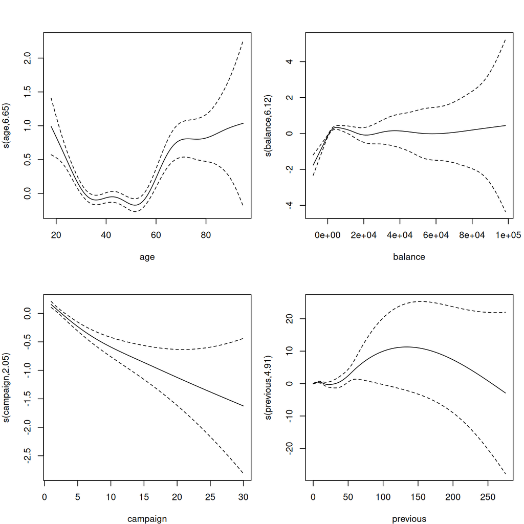

Estimated smooth effects on log-odds of subscription

```r
par(mfrow = c(2, 2), mar = c(4, 4, 3, 1))
plot(gam_fit, shade = TRUE, shade.col = "lightblue",
     seWithMean = TRUE, scale = 0, residuals = FALSE)
```

```r
par(mfrow = c(1, 1))
```

**Interpretation of smooth terms:**

## 10.3 Model Evaluation

```r
pred_prob_gam  <- as.vector(predict(gam_fit, newdata = bank_test, type = "response"))
pred_class_gam <- factor(if_else(pred_prob_gam > 0.5, "Yes", "No"),
                         levels = c("No", "Yes"))

cm_gam  <- confusionMatrix(pred_class_gam, bank_test_truth, positive = "Yes")
roc_gam <- roc(bank_test_truth_bin, pred_prob_gam)
auc_gam <- as.numeric(auc(roc_gam))

data.frame(
  Metric = c("Accuracy", "Sensitivity", "Specificity", "Balanced Accuracy", "AUC"),
  Value  = round(c(
    cm_gam$overall["Accuracy"],
    cm_gam$byClass["Sensitivity"],
    cm_gam$byClass["Specificity"],
    cm_gam$byClass["Balanced Accuracy"],
    auc_gam
  ), 3)
) %>% kable(caption = "GAM — Performance Metrics", row.names = FALSE)
```

GAM — Performance Metrics

| Metric | Value |
| --- | --- |
| Accuracy | 0.894 |
| Sensitivity | 0.183 |
| Specificity | 0.989 |
| Balanced Accuracy | 0.586 |
| AUC | 0.780 |

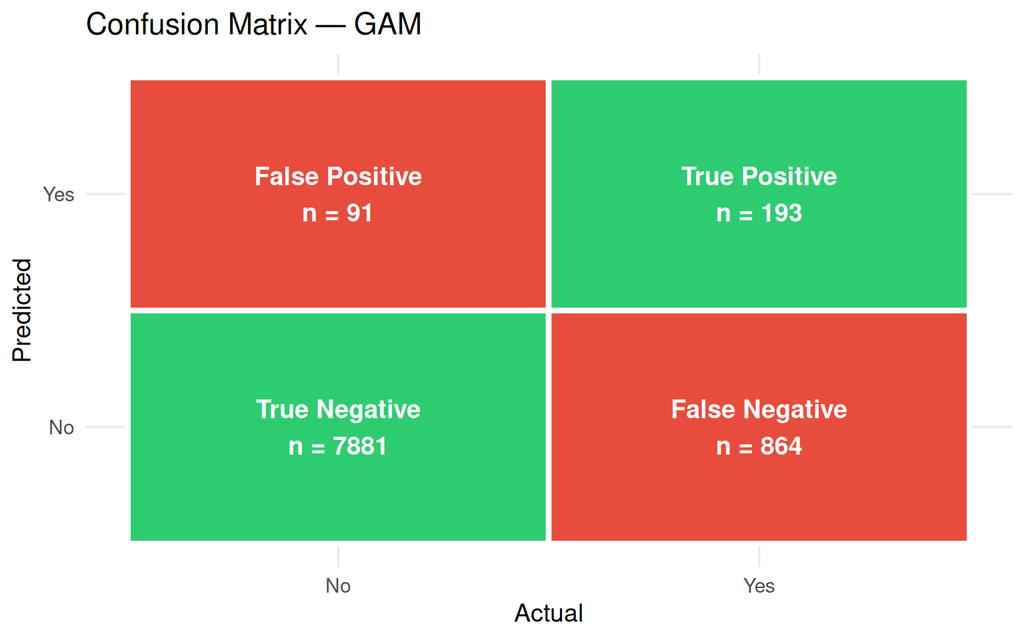

Confusion matrix — GAM

```r
as.data.frame(cm_gam$table) %>%
  mutate(label = case_when(
    Prediction == "No"  & Reference == "No"  ~ "True Negative",
    Prediction == "Yes" & Reference == "Yes" ~ "True Positive",
    Prediction == "Yes" & Reference == "No"  ~ "False Positive",
    Prediction == "No"  & Reference == "Yes" ~ "False Negative"
  )) %>%
  ggplot(aes(x = Reference, y = Prediction, fill = label)) +
  geom_tile(colour = "white", linewidth = 1.5) +
  geom_text(aes(label = paste0(label, "\nn = ", Freq)),
            size = 5, fontface = "bold", colour = "white") +
  scale_fill_manual(values = c(
    "True Positive"  = "#2ecc71", "True Negative"  = "#2ecc71",
    "False Positive" = "#e74c3c", "False Negative" = "#e74c3c"
  )) +
  labs(title = "Confusion Matrix — GAM", x = "Actual", y = "Predicted") +
  theme_minimal(base_size = 14) +
  theme(legend.position = "none")
```

## 10.4 GLM vs GAM Comparison

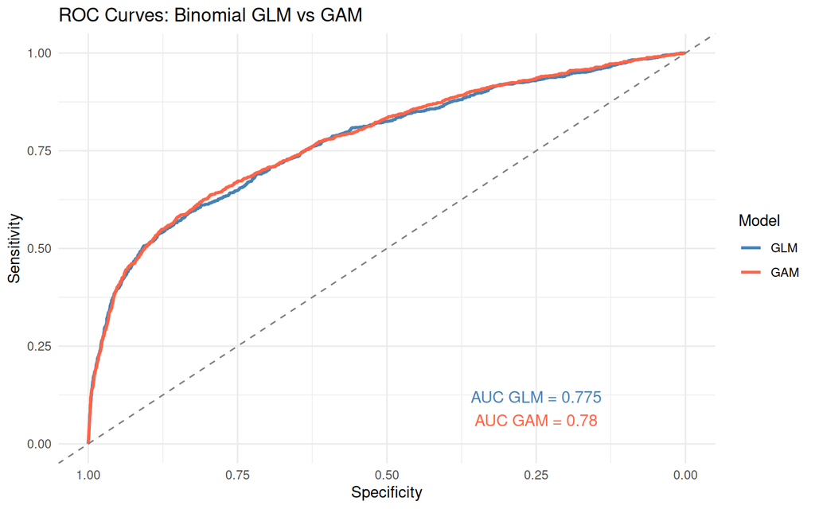

ROC curves: Binomial GLM vs GAM

```r
ggroc(list(GLM = roc_glm, GAM = roc_gam), size = 1) +
  geom_abline(slope = 1, intercept = 1, linetype = "dashed", colour = "grey50") +
  scale_colour_manual(values = c(GLM = "steelblue", GAM = "tomato")) +
  annotate("text", x = 0.25, y = 0.12,
           label = paste0("AUC GLM = ", round(auc_glm, 3)),
           colour = "steelblue", size = 4) +
  annotate("text", x = 0.25, y = 0.06,
           label = paste0("AUC GAM = ", round(auc_gam, 3)),
           colour = "tomato", size = 4) +
  labs(title = "ROC Curves: Binomial GLM vs GAM",
       x = "Specificity", y = "Sensitivity", colour = "Model") +
  theme_minimal()
```

```r
tibble(
  Model               = c("Binomial GLM", "GAM"),
  AUC                 = c(round(auc_glm, 4), round(auc_gam, 4)),
  Accuracy            = c(round(cm_glm$overall["Accuracy"], 4),          round(cm_gam$overall["Accuracy"], 4)),
  Sensitivity         = c(round(cm_glm$byClass["Sensitivity"], 4),       round(cm_gam$byClass["Sensitivity"], 4)),
  Specificity         = c(round(cm_glm$byClass["Specificity"], 4),       round(cm_gam$byClass["Specificity"], 4)),
  `Balanced Accuracy` = c(round(cm_glm$byClass["Balanced Accuracy"], 4), round(cm_gam$byClass["Balanced Accuracy"], 4))
) %>% kable(caption = "Binomial GLM vs GAM — side-by-side comparison")
```

Binomial GLM vs GAM — side-by-side comparison

| Model | AUC | Accuracy | Sensitivity | Specificity | Balanced Accuracy |
| --- | --- | --- | --- | --- | --- |
| Binomial GLM | 0.7751 | 0.8951 | 0.1741 | 0.9907 | 0.5824 |
| GAM | 0.7797 | 0.8942 | 0.1826 | 0.9886 | 0.5856 |

## 10.5 Discussion

The GAM captures non-linear effects the Binomial GLM misses — particularly the U-shaped age effect and diminishing returns for campaign contacts. For **model transparency**, the GLM remains valuable. For **prediction accuracy**, the GAM is preferable. Both models confirm the same core insight: focus on clients with a successful previous campaign outcome, contacted by mobile, in their first 1–2 calls of the current campaign.

# 11. Support Vector Machine (SVM) - Predicting subscribed

*Section lead: Aurelio Wyrsch*

Support Vector Machines are well-suited for binary classification tasks. Our target variable subscribed is binary (Yes/No), representing whether a client agreed to a term deposit during a phone campaign. By training an SVM to identify which clients are most likely to subscribe, the bank can prioritize its outreach towards high-probability leads — reducing campaign costs and improving conversion rates. Clients flagged as unlikely to subscribe can still be contacted if the budget allows, but resources are allocated more efficiently by targeting the most promising candidates first.

# 11.1 Feature Selection

Several variables are dropped before model training. duration is excluded since call duration is only known after a call is made, it cannot be used to predict subscription in a real deployment. The remaining dropped variables (pdays_clean, prev_contacted, balance_shifted, log_balance) are engineered features created for earlier modelling sections that are not needed.

```r
bank_clean <- bank_clean %>%
  select(-duration, -pdays_clean, -prev_contacted, -balance_shifted, -log_balance)
```

## 11.2 Train/Test Split

To evaluate how well a model generalizes unseen data, we split **bank_clean** into a training set (80%) and a test set (20%). Since the target variable **subscribed** is heavily imbalanced — around 88% “No” vs 12% “Yes” — a simple random split risks under-representing subscribers in one of the sets. We therefore use stratified sampling via **createDataPartition()**, which preserves the class proportions of subscribed in both the training and test set, ensuring neither set is accidentally dominated by one class.

```r
set.seed(123)
indices <- createDataPartition(bank_clean$subscribed, p = .80, list = F)

bank_train <- bank_clean %>%
  slice(indices)

bank_test <- bank_clean %>%
  slice(-indices) %>%
  select(-subscribed)

bank_test_truth <- bank_clean %>%
  slice(-indices) %>%
  pull(subscribed)
```

## 11.3 Cross Validation

To evaluate the SVM reliably, we use a 5-fold cross validation. Rather than evaluating the model on a single validation set, 5-fold cross validation splits the data into 5 folds, iteratively training on 4 folds and validating on the remaining fold. This process repeats 5 times so that every observation is used for validation exactly once. The result is a more stable and unbiased estimate of model performance compared to a single train/validation split.

```r
ctrl_svm <- trainControl(
  method = "cv",
  number = 5,
  classProbs = TRUE,
  summaryFunction = twoClassSummary,
  savePredictions = TRUE
  # verboseIter     = TRUE
)
```

## 11.4 Hyperparameter Tuning

To optimize the SVM’s performance, we tune two hyperparameters using a grid search. The grid search tests 20 combinations across cost = (0.01, 0.05, 0.1, 0.5, 1) and gamma = (0.05, 0.1, 0.5, 1), training and evaluating a separate model for each combination.

```r
tune_grid <- expand.grid(
  C     = c(0.01, 0.05, 0.1, 0.5, 1),
  sigma = c(0.05, 0.1, 0.5, 1) # gamma is called sigma in the caret package for svmRadial
)
```

## 11.5 Training

In the training, the model is evaluated using the 5-fold cross validation and grid search defined earlier. The combination that achieves the highest ROC is automatically selected as the final model. In total, 100 models are trained and compared in this process. Because of the class imbalance, a weighting was also added. Due to the computational demands of training a model 100 times on a large dataset, only a stratified 30% subsample of **bank_train** was used to speed up the process.

**Model:** svm(subscribed ~ . , data = bank_train_small, kernel = “radial”, gamma = x, cost = y),

- x = c(0.05, 0.1, 0.5, 1)
- y = c(0.01, 0.05, 0.1, 0.5, 1)

Out of all the combinations, the highest ROC score was achieved with cost = 0.05 and gamma = 0.05 at 0.7259016.

```r
set.seed(123)
small_indices <- createDataPartition(bank_train$subscribed, p = 0.3, list = F)
bank_train_small <- bank_train %>% slice(small_indices)

set.seed(123)
bank_svm <- train(
  subscribed ~ .,
  data       = bank_train_small,
  method     = "svmRadial",
  trControl  = ctrl_svm,
  tuneGrid   = tune_grid,
  metric     = "ROC",
  preProcess = c("center", "scale"),
  weights = ifelse(bank_train_small$subscribed == "Yes", 7.5, 1)
)
```

```r
bank_svm$results %>%
  filter(C == bank_svm$bestTune$C, sigma == bank_svm$bestTune$sigma)
```

| C | sigma | ROC | Sens | Spec | ROCSD | SensSD | SpecSD |
| --- | --- | --- | --- | --- | --- | --- | --- |
| 0.05 | 0.05 | 0.7259016 | 0.9885017 | 0.1527559 | 0.015983 | 0.003202416 | 0.02251335 |

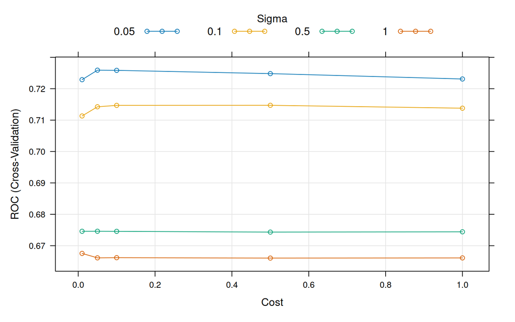

```r
plot(bank_svm)
```

## 11.6 Evaluting

```r
pred_svm <- factor(as.character(predict(bank_svm, bank_test)),
                   levels = c("No", "Yes"))

cm_svm <- confusionMatrix(pred_svm, bank_test_truth, positive = "Yes")

pred_svm_prob <- predict(bank_svm, bank_test, type = "prob")
roc_svm       <- roc(bank_test_truth, pred_svm_prob[, "Yes"])
auc_svm       <- as.numeric(auc(roc_svm))

svm_metrics <- data.frame(
  Metric = c("Accuracy", "Sensitivity", "Specificity",
             "Balanced Accuracy", "AUC"),
  Value  = round(c(
    cm_svm$overall["Accuracy"],
    cm_svm$byClass["Sensitivity"],
    cm_svm$byClass["Specificity"],
    cm_svm$byClass["Balanced Accuracy"],
    auc_svm
  ), 3)
)

kable(svm_metrics,
      caption = "SVM Model Performance Metrics",
      row.names = FALSE)
```

SVM Model Performance Metrics

| Metric | Value |
| --- | --- |
| Accuracy | 0.892 |
| Sensitivity | 0.142 |
| Specificity | 0.991 |
| Balanced Accuracy | 0.567 |
| AUC | 0.729 |

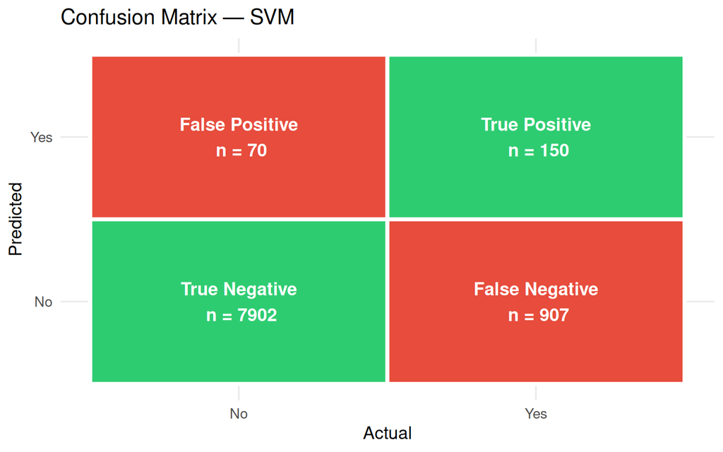

```r
cm_plot_data <- as.data.frame(cm_svm$table) %>%
  mutate(
    label = case_when(
      Prediction == "No"  & Reference == "No"  ~ "True Negative",
      Prediction == "Yes" & Reference == "Yes" ~ "True Positive",
      Prediction == "Yes" & Reference == "No"  ~ "False Positive",
      Prediction == "No"  & Reference == "Yes" ~ "False Negative"
    )
  )


ggplot(cm_plot_data, aes(x = Reference, y = Prediction, fill = label)) +
  geom_tile(color = "white", linewidth = 1.5) +
  geom_text(aes(label = paste0(label, "\n n = ", Freq)),
            size = 5, fontface = "bold", color = "white") +
  scale_fill_manual(values = c(
    "True Positive"  = "#2ecc71",
    "True Negative"  = "#2ecc71",
    "False Positive" = "#e74c3c",
    "False Negative" = "#e74c3c"
  )) +
  labs(
    title    = "Confusion Matrix — SVM",
    x        = "Actual",
    y        = "Predicted"
  ) +
  theme_minimal(base_size = 14) +
  theme(legend.position = "none")
```

# 12. Neural Networks - Predicting subscribed

*Section lead: Aurelio Wyrsch*

Like SVM, neural networks can be used on classification tasks. By using the attributes as input nodes and the target variable **subscribed** as the output node, a neural network can learn complex, non-linear relationships between the features and the likelihood of subscription. This allows the bank to capture subtle patterns in the data that may indicate a client’s propensity to subscribe, enabling more accurate predictions and better targeting of marketing efforts.

## 12.1 Training

Unlike for SVM, this time we don’t use cross validation and hyperparameter tuning. Instead, we directly train a single model on the full training set. To address the class imbalance, we apply class weights during training, like we did for SVM, giving more importance to the minority class (subscribers) to help the model learn from those examples.

**Model:** nnet(subscribed ~ . , data = bank_train, size = 8, decay = 0.1, maxit = 500, weights = nnt_weights, trace = FALSE)

```r
nnt_weights <- ifelse(bank_train$subscribed == "Yes", 7.5, 1)

set.seed(123)
bank_nnt <- nnet(subscribed ~ . , data = bank_train, size = 8, decay = 0.1, maxit = 500, weights = nnt_weights, trace = FALSE)
```

## 12.2 Evaluating

At a first glance, it looks like the neural network performed worse than the SVM, because the accuracy is now only 80.1%. Also the specificity is less with only 82.2% compared to 99.1% from SVM. However, the neural network outperforms the SVM across the other metrics, confirming that it is better suited for this classification task. The balanced accuracy of 0.734 represents a substantial improvement over the SVM’s 0.567, indicating the model is now meaningfully distinguishing between subscribers and non-subscribers rather than defaulting to the majority class. As mentioned, the specificity of the model correctly identifies 82.2% of non-subscribers, while the sensitivity now successfully catches 64.6% of actual subscribers — a dramatic improvement over the SVM’s 14.2%.

```r
pred_nnt <- factor(as.character(predict(bank_nnt, bank_test, type = "class")),
                   levels = c("No", "Yes"))

cm_nnt <- confusionMatrix(pred_nnt, bank_test_truth, positive = "Yes")

pred_nnt_prob <- predict(bank_nnt, bank_test, type = "raw")
roc_nnt       <- roc(bank_test_truth, pred_nnt_prob[, 1])
auc_nnt       <- as.numeric(auc(roc_nnt))

nnt_metrics <- data.frame(
  Metric = c("Accuracy", "Sensitivity", "Specificity",
             "Balanced Accuracy", "AUC"),
  Value  = round(c(
    cm_nnt$overall["Accuracy"],
    cm_nnt$byClass["Sensitivity"],
    cm_nnt$byClass["Specificity"],
    cm_nnt$byClass["Balanced Accuracy"],
    auc_nnt
  ), 3)
)

kable(nnt_metrics,
      caption   = "Neural Network Model Performance Metrics",
      row.names = FALSE)
```

Neural Network Model Performance Metrics

| Metric | Value |
| --- | --- |
| Accuracy | 0.801 |
| Sensitivity | 0.646 |
| Specificity | 0.822 |
| Balanced Accuracy | 0.734 |
| AUC | 0.789 |

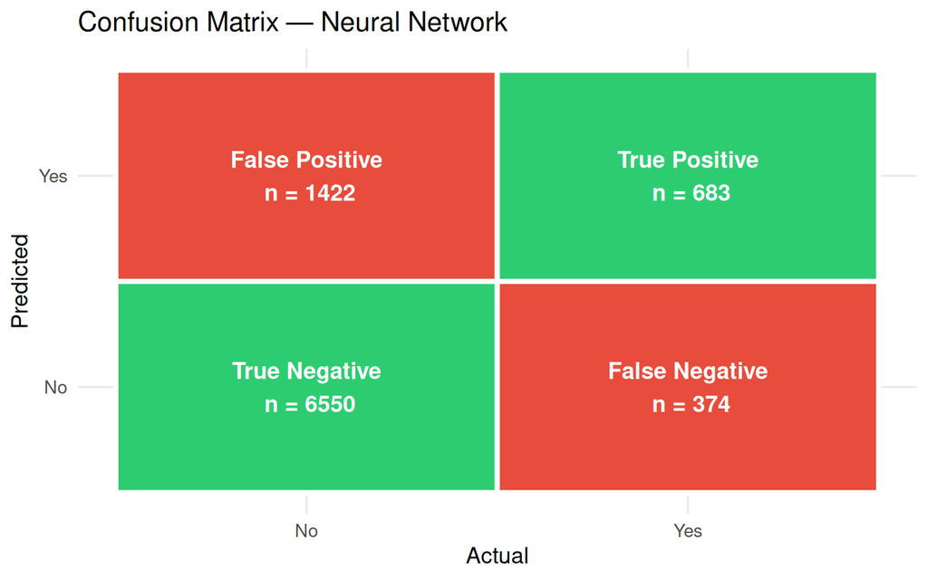

```r
cm_plot_data_nnt <- as.data.frame(cm_nnt$table) %>%
  mutate(
    label = case_when(
      Prediction == "No"  & Reference == "No"  ~ "True Negative",
      Prediction == "Yes" & Reference == "Yes" ~ "True Positive",
      Prediction == "Yes" & Reference == "No"  ~ "False Positive",
      Prediction == "No"  & Reference == "Yes" ~ "False Negative"
    )
  )

ggplot(cm_plot_data_nnt, aes(x = Reference, y = Prediction, fill = label)) +
  geom_tile(color = "white", linewidth = 1.5) +
  geom_text(aes(label = paste0(label, "\n n = ", Freq)),
            size = 5, fontface = "bold", color = "white") +
  scale_fill_manual(values = c(
    "True Positive"  = "#2ecc71",
    "True Negative"  = "#2ecc71",
    "False Positive" = "#e74c3c",
    "False Negative" = "#e74c3c"
  )) +
  labs(
    title    = "Confusion Matrix — Neural Network",
    x        = "Actual",
    y        = "Predicted"
  ) +
  theme_minimal(base_size = 14) +
  theme(legend.position = "none")
```

# 13. AI Usage

### Hanieh Jebeli

AI mainly helped with structuring the data cleaning process and speeding up coding tasks such as factor recoding and mutate() operations. It was also useful for understanding concepts like the offset term in the Poisson GLM, which I then verified using the course materials. Some suggestions required manual checking. For example, AI initially recommended a log transformation of balance without considering negative values, so I adjusted the approach by creating a shifted balance variable.

### Enerel Khuyag

AI was mainly used to support coding, debugging, and interpretation throughout the Binomial GLM and GAM sections. It helped speed up repetitive R tasks such as generating evaluation metrics, plotting ROC curves, formatting model outputs, and troubleshooting modelling or package-related errors. AI was also used to better understand the theoretical differences between GLMs and GAMs and to improve the clarity of model interpretations and explanations.

### Aurelio Wyrsch

AI was primarily used to speed up repetitive coding tasks such as writing visualisations and evaluation chunks consistently across model sections. It was also helpful for answering small implementation questions. Every AI-generated solution was manually reviewed and tested before being included in the report. This was done because some suggestions were incorrect or did not fit the specific context of the data.

# 14. Conclusion

The **Poisson GLM** revealed a U-shaped age effect: clients under 30 and above 60 subscribe at the highest rates. Education amplifies this effect tertiary-educated clients across all age groups subscribe more. Housing loans consistently reduce subscription rates, suggesting that existing financial commitments are a key barrier.

Together, these two models suggest that the bank should prioritise young and older clients with higher education and no housing loan and be cautious about over-contacting middle-aged clients who are the least responsive segment.

All four classification models were evaluated on the same held-out test set. The Binomial GLM and GAM performed similarly, achieving high accuracy (89%) but very low sensitivity (17–18%), meaning they correctly identified only a small fraction of actual subscribers. This is a direct consequence of the class imbalance — without any adjustment, both models default to predicting “No” for the vast majority of clients. The SVM, despite using class weights, showed similarly poor sensitivity (14.2%) and the lowest AUC (0.729), likely due to being trained on only 30% of the training data for computational reasons.

The Neural Network was the strongest performer overall. By applying class weights during training, it achieved a sensitivity of 64.6% and a balanced accuracy of 0.734 — substantially better than the other three models at identifying actual subscribers. Its AUC of 0.789 also edged out the GAM (0.780) and GLM (0.775). The trade-off is a drop in overall accuracy to 80.1%.